# All my homework

Yiran Chen

2024-12-07

# hw1

## Question

3.4Develop an algorithm to generate random samples from a Rayleigh(σ) distribution. Generate Rayleigh(σ) samples for several choices of σ > 0 and check that the mode of the generated samples is close to the theoretical mode σ (check the histogram).

## Answer

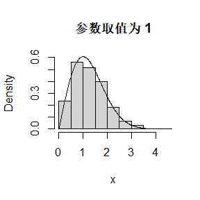

```r
R<-function(c,n=1000){
  set.seed(10)
  u<-runif(n)
  x<-sqrt(-2*c^2*log(1-u)) #逆变换生成所需分布
  #画直方图比较
  hist(x, prob = TRUE, ylim = c(0,0.6),main = paste("参数取值为",c))
  v <- seq(0, 10, .01)
  lines(v, v/(c^2)*exp(-v^2/(2*c^2)))
}  #看图可见所生随机数契合分布
R(1)
```

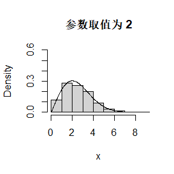

```r
R(2)
```

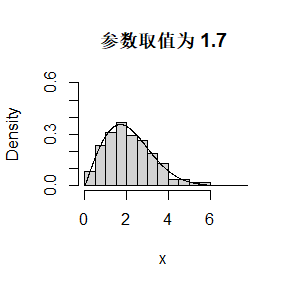

```r
R(1.7)
```

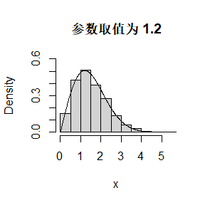

```r
R(1.2)
```

## Question

3.11Generate a random sample of size 1000 from a normal location mixture. The components of the mixture have N(0, 1) and N(3, 1) distributions with mixing probabilities p1 and p2 = 1 − p1. Graph the histogram of the sample with density superimposed, for p1 = 0.75. Repeat with different values for p1 and observe whether the empirical distribution of the mixture appears to be bimodal. Make a conjecture about the values of p1 that produce bimodal mixtures.

## Answer

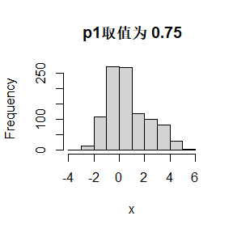

```r
mix<-function(p,n=1000){ #p=p1
  set.seed(10)
  x1<-rnorm(n,0,1)
  x2<-rnorm(n,3,1)
  a<-sample(0:1,n,replace = T,prob = c(1-p,p))
  x<-a*x1+(1-a)*x2
  hist(x,main = paste("p1取值为",p))
}
mix(0.75)#不显双峰
```

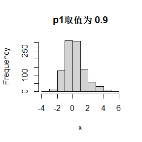

```r
mix(0.9)#不显双峰
```

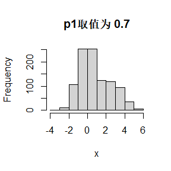

```r
mix(0.7)#不显双峰
```

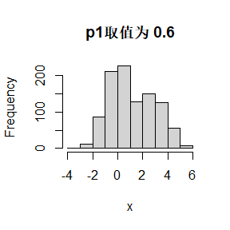

```r
mix(0.6)#显双峰
```

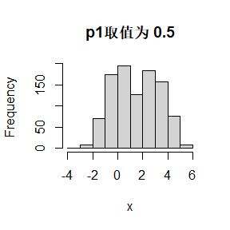

```r
mix(0.5)#显双峰
```

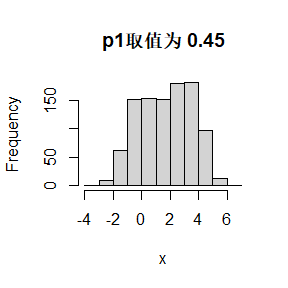

```r
mix(0.45)#不明显
```

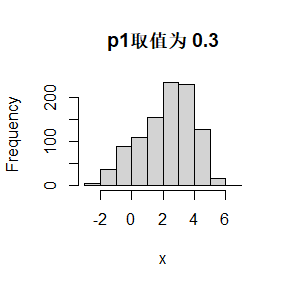

```r
mix(0.3)#不显双峰
```

## Question

3.20 A compound Poisson process is a stochastic process {X(t), t ≥ 0} that can be represented as the random sum X(t) = N( i=1 t) Yi, t ≥ 0, where {N(t), t ≥ 0} is a Poisson process and Y1, Y2,… are iid and independent of {N(t), t ≥ 0}. Write a program to simulate a compound Poisson(λ)–Gamma process (Y has a Gamma distribution). Estimate the mean and the variance of X(10) for several choices of the parameters and compare with the theoretical values. Hint: Show that E[X(t)] = λtE[Y1] and V ar(X(t)) = λtE[Y1 2].

## Answer

```r
p_g<-function(lambda,alpha,beta,t=10,n=10000){
  set.seed(100)
  Xt <- numeric(n)
  for (i in 1:n) {
    Nt <- rpois(1, lambda * t) # 生成 N(t)
    Yi <- rgamma(Nt, alpha, beta) # 生成伽马分布的随机变量
    Xt[i] <- sum(Yi) # 计算 X(t)
  } # 模拟复合泊松-伽马过程,生成Xt

# 估计均值和方差
estimated_mean <- mean(Xt)
estimated_var <- var(Xt)
# 理论值
theoretical_mean <- lambda * t * (alpha / beta)
theoretical_var <- lambda * t * ((alpha / beta)^2 + (alpha / beta^2))
# 输出结果
cat("估计的 X(10) 均值:", estimated_mean, "\n")
cat("估计的 X(10) 方差:", estimated_var, "\n")
cat("理论的 X(10) 均值:", theoretical_mean, "\n")
cat("理论的 X(10) 方差:", theoretical_var, "\n")
}

p_g(2,4,2)#参数选择：lambda:2,gamma:4,beta:2
```

```
## 估计的 X(10) 均值: 40.03082
## 估计的 X(10) 方差: 101.4416
## 理论的 X(10) 均值: 40
## 理论的 X(10) 方差: 100
```

```r
p_g(1,3,1/2)#参数选择：lambda:1,gamma:3,beta:1/2
```

```
## 估计的 X(10) 均值: 60.11594
## 估计的 X(10) 方差: 482.4459
## 理论的 X(10) 均值: 60
## 理论的 X(10) 方差: 480
```

```r
p_g(5,2,3)#参数选择：lambda:5,gamma:2,beta:3
```

```
## 估计的 X(10) 均值: 33.33009
## 估计的 X(10) 方差: 32.8553
## 理论的 X(10) 均值: 33.33333
## 理论的 X(10) 方差: 33.33333
```

# hw2

## Question

Write a function to compute a Monte Carlo estimate of the Beta(3, 3) cdf, and use the function to estimate F(x) for x = 0.1, 0.2,…, 0.9. Compare the estimates with the values returned by the pbeta function in R

## Answer

```r
Fbeta<-function(x,n=10000){
  set.seed(123)
  u<-runif(n,0,x)
  return(30*x*mean(u^2*(1-u)^2))
} #估计密度的函数
for (i in 1:9) {
  print(paste0("x=",i/10,"时,","估计值为",Fbeta(i/10),";pbeta值为",pbeta(i/10,3,3)))
}
```

```
## [1] "x=0.1时,估计值为0.00847526141155528;pbeta值为0.00856"
## [1] "x=0.2时,估计值为0.057406500602379;pbeta值为0.05792"
## [1] "x=0.3时,估计值为0.161834409456813;pbeta值为0.16308"
## [1] "x=0.4时,估计值为0.315483183130893;pbeta值为0.31744"
## [1] "x=0.5时,估计值为0.497810716725118;pbeta值为0.5"
## [1] "x=0.6时,估计值为0.681058801957226;pbeta值为0.68256"
## [1] "x=0.7时,估计值为0.837303323834966;pbeta值为0.83692"
## [1] "x=0.8时,估计值为0.945504457328872;pbeta值为0.94208"
## [1] "x=0.9时,估计值为0.998556864045035;pbeta值为0.99144"
```

## Question

Implement a function to generate samples from a Rayleigh(σ) distribution, using antithetic variables. What is the percent reduction in variance?

## Answer

```r
f_duiou<-function(sigma,n=1000){
  set.seed(123)
  U<-runif(n/2)
  x1<-sqrt(-2*sigma^2*log(1-U))
  x2<-sqrt(-2*sigma^2*log(U))
  return(c(x1,x2))
}  #对偶生成
f<-function(sigma,n=1000){
  set.seed(123)
  U<-runif(n)
  x<-sqrt(-2*sigma^2*log(1-U))
  return(x)
}  #独立生成

#比较方差
for (i in c(0.5,1,5)) {
  a<-round(var(f_duiou(i)),3)
  b<-round(var(f(i)),3)
  print(paste0("sigma=",i,"时,","对偶生成方差为",a,";独立生成方差值为",b,"相比方差减少:",round(((b-a)/b)*100,3),"%"))
}
```

```
## [1] "sigma=0.5时,对偶生成方差为0.104;独立生成方差值为0.105相比方差减少:0.952%"
## [1] "sigma=1时,对偶生成方差为0.414;独立生成方差值为0.421相比方差减少:1.663%"
## [1] "sigma=5时,对偶生成方差为10.351;独立生成方差值为10.516相比方差减少:1.569%"
```

## Question

Find two importance functions f1 and f2 that are supported on (1, ∞) and are ‘close’ to g(x),Which of your two importance functions should produce the smaller variance in estimating by importance sampling? Explain.

## Answer

two importance functions f1 and f2:
$$f_1=xe^{-x^2/2}\hspace{1cm}(x>1)$$
$$f_2=\frac{1}{\sqrt
{2\pi}}e^{-x^2/2}\hspace{1cm}(x>1)$$

```r
n<-1000
set.seed(123)
a1<-f(1,5000)
a2<-rnorm(15000)
a1<-a1[a1>1][1:n]
a2<-a2[a2>1][1:n]
g1<-a1/sqrt(2*pi*exp(1))
g2<-0.1587*a2^2
paste0("f1为重要函数的估计均值为：",mean(g1))
```

```
## [1] "f1为重要函数的估计均值为：0.395953093796884"
```

```r
paste0("f2为重要函数的估计均值为",mean(g2))
```

```
## [1] "f2为重要函数的估计均值为0.395750589981665"
```

```r
paste0("f1为重要函数的估计方差为：",var(g1))
```

```
## [1] "f1为重要函数的估计方差为：0.0148768513952457"
```

```r
paste0("f2为重要函数的估计方差为",var(g2))
```

```
## [1] "f2为重要函数的估计方差为0.0727565385799206"
```

f1(The Rayleigh density) produce the smaller variance.

## Question

apply the fast sorting algorithm to randomly permuted numbers

## Answer

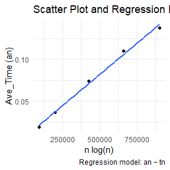

```r
library(ggplot2)
set.seed(123)
#快排函数
quick <- function(x) {
  if (length(x) <= 1) {
    return(x)
  } else {
    pivot <- x[1]
    less <- quick(x[x < pivot])
    greater <- quick(x[x > pivot])
    return(c(less, pivot, greater))
  }
}

# 定义计算排序时间的函数
time <- function(n) {
  numbers <- sample(1:n)
  a<-Sys.time()
  quick(numbers)
  b<-Sys.time()
  return(b-a)
}
# 定义n的值
n <- c(10^4, 2*10^4, 4*10^4, 6*10^4, 8*10^4)

# 初始化存储计算时间的向量
av_time <- c()

# 对每个n值进行100次模拟
for (i in 1:length(n)) {
  n1 <- n[i]
  times <- replicate(100, time(n1))
  av_time[i] <- mean(times)
}

# 计算n log(n)
tn <- n * log(n)

# 绘制散点图和回归线
ggplot(data.frame(tn, av_time), aes(x = tn, y = av_time)) +
  geom_point() +
  geom_smooth(method = "lm", se = FALSE) +
  labs(title = "Scatter Plot and Regression Line",
       x = "n log(n)",
       y = "Ave_Time (an)",
       caption = "Regression model: an ~ tn") +
  theme_minimal()
```

# hw3

## Question

Estimate the 0.025, 0.05, 0.95, and 0.975 quantiles of the skewness √b1 under normality by a Monte Carlo experiment. Compute the standard error of the estimates from (2.14) using the normal approximation for the density (with exact variance formula). Compare the estimated quantiles with the quantiles of the large sample approximation √b1 ≈ N(0, 6/n).

## Answer

```r
n<-1000 #样本量
m<-1000 #模拟次数
set.seed(10)
#计算样本偏度
b<-numeric(m)
for (i in 1:m) {
  x<-rnorm(n)
  b[i]<-mean(((x-mean(x))/sd(x))^3)
}
#分位数估计
qvalue<-quantile(b, probs = c(0.025,0.05,0.95,0.975))
qvalue
```

```
##       2.5%         5%        95%      97.5%
## -0.1534534 -0.1320655  0.1294433  0.1628810
```

```r
# Compute the standard error
q<-c(0.025,0.05,0.95,0.975)
sd<-sqrt(q*(1-q)/(m*(dnorm(quantile(b,probs = q),0,sqrt(6/n)))^2))
print("the standard error of the estimates:")
```

```
## [1] "the standard error of the estimates:"
```

```r
sd
```

```
##        2.5%          5%         95%       97.5%
## 0.006821295 0.005724458 0.005406503 0.008745772
```

```r
# Compare the estimated quantiles with the quantiles of the large sample approximation
print("the estimated quantiles:")
```

```
## [1] "the estimated quantiles:"
```

```r
qvalue
```

```
##       2.5%         5%        95%      97.5%
## -0.1534534 -0.1320655  0.1294433  0.1628810
```

```r
print("the quantiles of the large sample approximation:")
```

```
## [1] "the quantiles of the large sample approximation:"
```

```r
qnorm(c(0.025, 0.05, 0.95, 0.975), mean = 0, sd = sqrt(6/n))
```

```
## [1] -0.1518182 -0.1274098  0.1274098  0.1518182
```

估计的分位数和大样本估计的分位数近似

## Question

Tests for association based on Pearson product moment correlation ρ, Spearman’s rank correlation coefficient ρs, or Kendall’s coefficient τ, are implemented in cor.test. Show (empirically) that the nonparametric tests based on ρs or τ are less powerful than the correlation test when the sampled distribution is bivariate normal. Find an example of an alternative (a bivariate distribution (X, Y ) such that X and Y are dependent) such that at least one of the nonparametric tests have better empirical power than the correlation test against this alternative.

## Answer

```r
library(MASS)
library(mvtnorm)
```

```r
set.seed(10)
# 生成双变量正态样本
n <- 1000
mu <- c(0, 0)  # 均值
sd <- matrix(c(1, 0.7, 0.7, 1), 2, 2)  # 协方差
data <- mvrnorm(n, mu, sd)
X <- data[, 1]
Y <- data[, 2]
# 相关性检验
pea <- cor.test(X, Y, method = "pearson")
spe <- cor.test(X, Y, method = "spearman")
ken <- cor.test(X, Y, method = "kendall")

print(paste0("Pearson product moment correlation:",round(pea$estimate,3)))
```

```
## [1] "Pearson product moment correlation:0.673"
```

```r
print(paste0("Spearman’s rank correlation coefficient:",round(spe$estimate,3)))
```

```
## [1] "Spearman’s rank correlation coefficient:0.663"
```

```r
print(paste0("Kendall’s coefficient:",round(ken$estimate,3)))
```

```
## [1] "Kendall’s coefficient:0.473"
```

可见对于双变量正态，相关性检验估计中Pearson-test最有效。

对于二元t分布：

```r
df <- 10
mean <- c(0, 0)
Sigma <- matrix(c(1, 0.8, 0.8, 1), nrow = 2)
# 生成样本
set.seed(10)
n <- 10  # 样本大小
data <- rmvt(n, delta = mean, sigma = Sigma, df = df)
X <- data[, 1]
Y <- data[, 2]
# 相关性检验
pea <- cor.test(X, Y, method = "pearson")
spe <- cor.test(X, Y, method = "spearman")
ken <- cor.test(X, Y, method = "kendall")

print(paste0("Pearson product moment correlation:",round(pea$estimate,3)))
```

```
## [1] "Pearson product moment correlation:0.97"
```

```r
print(paste0("Spearman’s rank correlation coefficient:",round(spe$estimate,3)))
```

```
## [1] "Spearman’s rank correlation coefficient:0.903"
```

```r
print(paste0("Kendall’s coefficient:",round(ken$estimate,3)))
```

```
## [1] "Kendall’s coefficient:0.778"
```

可见当样本量比较小时，Kendall相关性检验表现出比Pearson更好的估计效果；

```r
X <- data[, 1]
Y <- data[, 1]^3+data[,1]
# 相关性检验
pea <- cor.test(X, Y, method = "pearson")
spe <- cor.test(X, Y, method = "spearman")
ken <- cor.test(X, Y, method = "kendall")

print(pea)
```

```
##
##  Pearson's product-moment correlation
##
## data:  X and Y
## t = 10.113, df = 8, p-value = 7.805e-06
## alternative hypothesis: true correlation is not equal to 0
## 95 percent confidence interval:
##  0.8470043 0.9914790
## sample estimates:
##       cor
## 0.9630433
```

```r
print(spe)
```

```
##
##  Spearman's rank correlation rho
##
## data:  X and Y
## S = 3.6637e-14, p-value < 2.2e-16
## alternative hypothesis: true rho is not equal to 0
## sample estimates:
## rho
##   1
```

```r
print(ken)
```

```
##
##  Kendall's rank correlation tau
##
## data:  X and Y
## T = 45, p-value = 5.511e-07
## alternative hypothesis: true tau is not equal to 0
## sample estimates:
## tau
##   1
```

上述结果可见，对于非线性相关的情况，Spearman和Kendall检验相比于Pearson检验有更小的p值。

## Question

If we obtain the powers for two methods under a particular simulation setting with 10,000 experiments: say, 0.651 for one method and 0.676 for another method. Can we say the powers are different at 0.05 level?

## Answer

The corresponding hypothesis test problem:
$$H_0:两种检验方法功效相同，即p_1-p_2=0$$
$$H_1:两种检验方法功效不同，即p_1-p_2\neq
0$$

对于上述假设检验问题，我们可以使用paired-t检验或者 McNemar检验。Z检验和两样本t检验需要两样本独立性，而在这个问题下两组检验结果具有相关性，所以不适用；而paired-t检验可以用来比较两样本相关性，McNemar检验是对配对名义数据的假设检验，常用于检验两模型的性能，因此我们选用McNemar检验。

选用McNemar检验，除了题目中的信息（10,000 experiments，0.651 for one method and 0.676 for another method，0.05 level），至少还需要知道10000次实验中，同时落入两种方法的拒绝域的次数（从而才能得到2*2列联表进行McNemar检验）

```r
library(coin)
# 代码举例：同时落入两种方法的拒绝域的次数400
da <- matrix(c(400, 251, 276, 73), nrow = 2, byrow = TRUE,
                dimnames = list(Method1 = c("Positive", "Negative"),
                                Method2 = c("Positive", "Negative")))
print(da)
```

```
##           Method2
## Method1    Positive Negative
##   Positive      400      251
##   Negative      276       73
```

```r
# 进行McNemar检验
mcnemar.test(da)
```

```
##
##  McNemar's Chi-squared test with continuity correction
##
## data:  da
## McNemar's chi-squared = 1.093, df = 1, p-value = 0.2958
```

# hw4

## Question

Of N = 1000 hypotheses, 950 are null and 50 are alternative. The p-value under any null hypothesis is uniformly distributed (use runif), and the p-value under any alternative hypothesis follows the beta distribution with parameter 0.1 and 1 (use rbeta). Obtain Bonferroni adjusted p-values and B-H adjusted p-values. Calculate FWER, FDR, and TPR under nominal level α = 0.1 for each of the two adjustment methods based on m = 10000 simulation replicates.

## Answer

```r
set.seed(123)
h0<-numeric(950)
h1<-numeric(50)
m<-10000
FWER1<-FDR1<-TPR1<-numeric(m)
FWER2<-FDR2<-TPR2<-numeric(m)
for (i in 1:m) {
  h0<-runif(950)
  h1<-rbeta(50,0.1,1)
  h<-c(h0,h1)
  h_bon<-p.adjust(h,method='bonferroni')
  h_bh<-p.adjust(h,method='fdr')
  #计算FWER, FDR, and TPR of bonferroni
  h0_bon<-p.adjust(h0,method='bonferroni')
  FWER1[i]<-ifelse(any(h0_bon<0.1),1,0)
  FDR1[i]<-sum(h_bon[1:950]<0.1)/sum(h_bon<0.1)
  TPR1[i]<-sum(h_bon[951:1000]<0.1)/50
  #计算FWER, FDR, and TPR of B-H
  h0_bh<-p.adjust(h0,method='fdr')
  FWER2[i]<-ifelse(any(h0_bh<0.1),1,0)
  FDR2[i]<-sum(h_bh[1:950]<0.1)/sum(h_bh<0.1)  #####
  TPR2[i]<-sum(h_bh[951:1000]<0.1)/50   #####
}

# 将结果整理成3*2表格
results <- matrix(round(c(mean(FWER1),mean(FWER2),mean(FDR1),mean(FDR2),mean(TPR1),mean(TPR2)),4), nrow = 3, ncol = 2,byrow = T)
colnames(results) <- c("Bonferroni校正", "B-H校正")
rownames(results) <- c("FWER", "FDR", "TPR")
print(results)
```

```
##      Bonferroni校正 B-H校正
## FWER         0.0911  0.0958
## FDR          0.0045  0.0950
## TPR          0.3967  0.5611
```

## Question

Assume that the times between failures follow an exponential model Exp(λ). Obtain the MLE of the hazard rate λ and use bootstrap to estimate the bias and standard error of the estimate

## Answer

```r
library(boot)
set.seed(123)
x<-c(3, 5, 7, 18, 43, 85, 91, 98, 100, 130, 230, 487)
mle<-function(x,i) 1/mean(x[i])
obj <- boot(data=x,statistic=mle,R=1e4)
print(paste0("lamda的MLE估计为：",round(obj$t0,4)))
```

```
## [1] "lamda的MLE估计为：0.0093"
```

```r
print(paste0(" estimate the bias of the estimate：",round(mean(obj$t)-obj$t0,4)))
```

```
## [1] " estimate the bias of the estimate：0.0014"
```

```r
print(paste0(" estimate the standard error of the estimate：",round(sd(obj$t),4)))
```

```
## [1] " estimate the standard error of the estimate：0.0044"
```

## Question

Refer to Exercise 7.4. Compute 95% bootstrap confidence intervals for the mean time between failures 1/λ by the standard normal, basic, percentile, and BCa methods. Compare the intervals and explain why they may differ.

## Answer

```r
me<-function(x,i) mean(x[i])
de <- boot(data=x,statistic=me,R=1e4)
ci <- boot.ci(de,type=c("norm","basic","perc","bca"))
print("四种CI分别为(区间下界 区间上界)：")
```

```
## [1] "四种CI分别为(区间下界 区间上界)："
```

```r
ci$normal[2:3]
```

```
## [1]  32.57798 182.37797
```

```r
ci$basic[4:5]
```

```
## [1]  24.42293 169.41667
```

```r
ci$percent[4:5]
```

```
## [1]  46.7500 191.7437
```

```r
ci$bca[4:5]
```

```
## [1]  57.12448 232.40698
```

四种方法得到的置信区间不同，这是因为norm方法是在渐进正态假设下的区间；basic方法是基于大样本属性引导出来的，percile是直接从模拟生成的thetastar分布得到置信区间的；而BCa则是更为复杂的偏差校正和加速。它们各自方法原理不同，故生成的置信区间也有差异。

# hw5

## Question

Refer to Exercise 7.7. Obtain the jackknife estimates of bias and standard error of θ

## Answer

```r
rm(list = ls())
library(bootstrap)
data1<-data(scor)
```

```r
set.seed(123)
#求jackknife的函数
knife<-function(data0){
  n<-nrow(data0)
  ei<-matrix(NA,n,5)
  for (i in 1:n) {
    sigma<-cor(data0[-i,])
    ei[i,]<-eigen(sigma)$values
  } # ei为特征值矩阵
  jacktheta<-ei[,1]/(ei[,1]+ei[,2]+ei[,3]+ei[,4]+ei[,5])
  return(jacktheta)
}
```

```r
#theta_hat
sigma<-cor(scor)
ei<-eigen(sigma)$values
theta<-ei[1]/sum(ei)
thetaj<-knife(scor)
#the jackknife estimates of bias
(nrow(scor)-1)*(mean(thetaj)-theta)
```

```
## [1] -0.0003778535
```

```r
#the jackknife estimates of standard error of θ
sqrt((nrow(scor)-1)*mean((thetaj-theta)^2))
```

```
## [1] 0.04466686
```

## Question

In Example 7.18, leave-one-out (n-fold) cross validation was used to select the best fitting model. Repeat the analysis replacing the Log-Log model with a cubic polynomial model. Which of the four models is selected by the cross validation procedure? Which model is selected according to maximum adjusted R2?